# Price prediction for Airbnb listings in Toronto

# Technical report

Created by Zsófia Rebeka Katona

Data Analysis 3

MS in Business Analytics

2023/2024 Winter term

**Aim of the report:** To show the technical aspects of the data set, including data cleaning, feature engineering, model selection and model visualization.

**Project goal:** To provide an overview on Airbnb price listings for a company, operating with accommodations to 2-6 guests. My recommendations for pricing and further views based on my findings can be found in the report.

## About the dataset

- The data set contains 20,386 Airbnb listings, spanning across various attributes including host details, property characteristics, pricing, availability, and guest reviews.
- The data contains 238,342 missing values in total.
- Features, like `accommodates`, `beds`, `number_if_review`, and `review_scores_rating` are expected to be significant predictors of the target variable.

**Data source:** Inside Airbnb

**More information on the Airbnb listings in Toronto:** Toronto Summary

# Data importing

```python
# Importing data from github
data = pd.read_csv('https://raw.githubusercontent.com/zsofiarebeka/DA3_Assignment-2/main/Toronto_listings.csv')
```

```python
# Checking the data
data.head()
```

|  | id | listing_url | scrape_id | last_scraped | source | name | description | neighborhood_overview | picture_url | host_id | ... | review_scores_communication | review_scores_location | review_scores_value | license | instant_bookable | calculated_host_listings_count | calculated_host_listings_count_entire_homes | calculated_host_listings_count_private_rooms | calculated_host_listings_count_shared_rooms | reviews_per_month |
| --- | --- | --- | --- | --- | --- | --- | --- | --- | --- | --- | --- | --- | --- | --- | --- | --- | --- | --- | --- | --- | --- |
| 0 | 24018771 | https://www.airbnb.com/rooms/24018771 | 20240108030557 | 2024-01-08 | city scrape | Home in Toronto · ★4.74 · 1 bedroom · 1 bed · ... | NaN | NaN | https://a0.muscache.com/pictures/1030ee76-f3f7... | 179038571 | ... | 4.78 | 4.77 | 4.72 | STR-2009-FDSXPB | f | 3 | 0 | 3 | 0 | 1.83 |
| 1 | 50680103 | https://www.airbnb.com/rooms/50680103 | 20240108030557 | 2024-01-08 | city scrape | Boat in Toronto · 1 bedroom · 1 bath | NaN | NaN | https://a0.muscache.com/pictures/91f84c43-e010... | 396389036 | ... | NaN | NaN | NaN | Exempt | t | 1 | 1 | 0 | 0 | NaN |
| 2 | 1018845223985730763 | https://www.airbnb.com/rooms/1018845223985730763 | 20240108030557 | 2024-01-08 | city scrape | Townhouse in Toronto · ★New · 1 bedroom · 1 be... | NaN | NaN | https://a0.muscache.com/pictures/f1e047ed-949d... | 9660032 | ... | NaN | NaN | NaN | NaN | t | 4 | 1 | 3 | 0 | NaN |
| 3 | 842991103042611460 | https://www.airbnb.com/rooms/842991103042611460 | 20240108030557 | 2024-01-08 | city scrape | Bed and breakfast in Toronto · ★4.67 · 1 bedro... | NaN | NaN | https://a0.muscache.com/pictures/miso/Hosting-... | 128444795 | ... | 5.00 | 5.00 | 5.00 | STR-2011-GTCKVH | f | 1 | 0 | 1 | 0 | 0.51 |
| 4 | 1004965626999219484 | https://www.airbnb.com/rooms/1004965626999219484 | 20240108030557 | 2024-01-08 | city scrape | Home in Toronto · ★4.73 · 1 bedroom · 4 beds ·... | NaN | NaN | https://a0.muscache.com/pictures/miso/Hosting-... | 120551336 | ... | 5.00 | 4.93 | 4.80 | STR-2310-GYFHHV | f | 1 | 0 | 1 | 0 | 6.92 |

5 rows × 75 columns

```python
# Checking out the info
data.info()
```

```
<class 'pandas.core.frame.DataFrame'>
RangeIndex: 20386 entries, 0 to 20385
Data columns (total 75 columns):
 #   Column                                        Non-Null Count  Dtype
---  ------                                        --------------  -----
 0   id                                            20386 non-null  int64
 1   listing_url                                   20386 non-null  object
 2   scrape_id                                     20386 non-null  int64
 3   last_scraped                                  20386 non-null  object
 4   source                                        20386 non-null  object
 5   name                                          20386 non-null  object
 6   description                                   0 non-null      float64
 7   neighborhood_overview                         11337 non-null  object
 8   picture_url                                   20386 non-null  object
 9   host_id                                       20386 non-null  int64
```

[output cut: 67 more lines]

```python
data.isna().sum().sum()
```

```
238342
```

## Data cleaning

- Data cleaning included dropping unneccessary columns, 16 in total out of 75, leaving 59 variables to work with.
- I transformed the binary columns to booleans, turning t/f values to `True` or `False`.
- I converted columns from `object` to `datetime` or `percentages`.
- I cleaned the target variable, `price` column, transformed it to `float` type, dropped all NA values and renamed the column to `usd_price_day`.
- I filtered for 2-6 number of guests.
- I filtered for the property tpyes that correspond to small or mid-sized apartments and categorized them into `Rental Unit` or `House` for a more transparent comparison.
- I renamed the room types.
- As the `bathrooms` column had too many missing values, I decided to use the `bathrooms_text` predictor and manually convert the string information to numeric.
- I pooled values where the results would have been to fragmented due to the large variety of values.
  - `bathrooms`: As we are talking about an apartment for 2-6 accommodates, it’s important to check if there is one or more bathrooms. Based on this, I created bins for apartments with 0, 1 and 2-10 bathrooms. I checked the number of reviews, where the mean was 27, and for simplicity and balance, I decided to bin the data according to that.
  - `number_of_review`
  - `minimum_nights`: Many travelers have preferences for staying for 1, 2, or 3 nights, especially for shorter trips or weekend getaways, hence I created bins according to that.
- I handled missing values with 3 different approaches:
  - I dropped everything in the target variable.
  - In instances of few missing values, I performed imputation by substituting missing values with the median or, for grouped variables, assigning them to the most frequent category.
  - In cases where there was a significant number of missing values, and alternative data could be leveraged, such as substituting `bedrooms` with `number of beds`, I opted for the alternative data column.
  - Certain columns like `calendar_updated` and `host_neighbourhood` were excluded from analysis due to their lack of relevance or informative value. However, for important factors like `neighborhood`, a cleaned version was utilized.
  - Notably, for critical variables, particularly `guest review metrics`, missing values were flagged.
- I transformed and renamed the columns with numerical variables, and renamed the categorical variables to oversee the data types easily.
- It’s important to mention that the `amenities` column didn’t contain any valuable information, possibly because the data was scraped recently, on the 8th of January, 2024.

```python
# Dropping columns that are not needed
data = data.drop(columns = ["listing_url",
                            "scrape_id",
                            "last_scraped",
                            "name",
                            "description",
                            "neighborhood_overview",
                            "picture_url",
                            "neighbourhood_group_cleansed",
                            "bathrooms",
                            "host_url",
                            "host_location",
                            "host_about",
                            "host_response_time",
                            "host_thumbnail_url",
                            "host_picture_url",
                            "license"
                            ])
```

```python
# Turning the columns with t/f values to binary columns and rename them
binary_columns = ["host_is_superhost",
                  "host_has_profile_pic",
                  "host_identity_verified",
                  "has_availability",
                  "instant_bookable"
                 ]
for col in binary_columns:
    data["d_" + col] = data[col].map({"t": 1, "f": 0})
```

```python
# Formatting columns with percentages
for perc in ["host_response_rate", "host_acceptance_rate"]:
    data[perc] = data[perc].replace("%", "", regex=True)
    data[perc] = pd.to_numeric(data[perc], errors="coerce")
```

```python
# Coverting time-related columns to datetime type of objects
datetime_columns = ["host_since",
                    "calendar_updated",
                    "calendar_last_scraped",
                    "first_review",
                    "last_review"
                    ]
for col in datetime_columns:
    data[col] = pd.to_datetime(data[col], errors = 'coerce')
```

```python
# Cleaning the price column from currency symbols and decimals
data.price = data.price.str.replace("$", "").str.replace(",", "")

# Removing rows with empty strings to be able to convert to float
data = data[data["price"] != ""]

# Turning the price column to float
data["price"] = data["price"].astype(float)

# Rename the price columns
data.rename(columns={"price": "usd_price_day"}, inplace=True)

# Dropping rows where price is missing
data = data.dropna(subset=['usd_price_day'])
```

```python
# Filtering for small and mid-size apartments hosting 2-6 guests
data = data[(data.accommodates >= 2) & (data.accommodates <= 6)]
```

## Feature Engineering

#### Property types variable

```python
# Only keeping the property types if they are small and mid-size apartments
data = data.loc[lambda x: x["property_type"].isin(["Entire rental unit",
                                                   "Entire condo",
                                                   "Private room in home",
                                                   "Entire home",
                                                   "Private room in rental unit",
                                                   "Entire loft",
                                                   "Entire serviced apartment",
                                                   "Entire home/apt",
                                                   "Shared room in rental unit",
                                                   "Shared room in home"
                                                  ])]
```

```python
# Categorizing the properties to Rental Unit or House catgeories
data['property_type'] = data['property_type'].apply(lambda x: 'Rental Unit' if "rental unit" in x else 'House')
```

#### Room types and bed variables

```python
# Renaming the room types as they are too long
data["room_type"] = data["room_type"].map({"Entire home/apt": "Entire/Apt",
                                          "Private room": "Private",
                                          "Shared room" : 'Shared'})
```

#### Bathrooms variable

```python
# Assigning numerical values to bathrooms
data["bathrooms_text"] = data["bathrooms_text"].map({"1 bath": 1,
                                                  "2 baths": 2,
                                                  "1 private bath": 1,
                                                  "1 shared bath": 1,
                                                  "1.5 baths": 1.5,
                                                  "2.5 baths": 2.5,
                                                  "1.5 shared baths": 1.5,
                                                  "2 shared baths": 2,
                                                  "3 baths": 3,
                                                  "3.5 baths": 3.5,
                                                  "4 baths": 4,
                                                  "3 shared baths": 3,
                                                  "0 baths": 0,
                                                  "5 baths": 5,
                                                  "4.5 baths" : 4.5,
                                                  "5.5 baths" : 5.5,
                                                  "8 baths" : 8,
                                                  "Private half-bath" : 0.5
                                                  })
```

### Pooling values

```python
# Pooling accomodations with 0, 1, 2-10 bathrooms

bins = pd.IntervalIndex.from_tuples([(0, 1), (1, 2), (2, 10)], closed="left")
f_bath = pd.cut(data["bathrooms"].to_list(), bins, labels=["0.0", "1.0", "2.0"])
f_bath.categories = [0, 1, 2]
data["bathrooms"] = f_bath

f_bath.value_counts(dropna=False)
```

```
0         8
1      9193
2      2175
NaN      28
dtype: int64
```

```python
# Pooling the number of reviews into three categories: none, 1-27 and over 27

bins = pd.IntervalIndex.from_tuples(
    [(0, 1), (1, 27), (27, max(data.number_of_reviews))], closed="left"
)
fnor = pd.cut(data["number_of_reviews"].to_list(), bins, labels=["0", "1", "2"])
fnor.categories = [0, 1, 2]
data["number_of_reviews"] = fnor
data["number_of_reviews"].value_counts(dropna=False)
```

```
1      5455
2      3005
0      2943
NaN       1
Name: number_of_reviews, dtype: int64
```

```python
# Pooling and categorizing the number of minimum nights: 1,2,3 and 3+

bins = pd.IntervalIndex.from_tuples(
    [(1, 2), (2, 3), (3, max(data.minimum_nights))], closed="left"
)
f_min_n = pd.cut(data["minimum_nights"].to_list(), bins, labels=["1", "2", "3"])
f_min_n.categories = [1, 2, 3]
data["minimum_nights"] = f_min_n
data["minimum_nights"].value_counts(dropna=False)
```

```
3      8504
1      1688
2      1211
NaN       1
Name: minimum_nights, dtype: int64
```

### Handling missing values

```python
# Transforming the Infinite values with NaNs
data = data.replace([np.inf, -np.inf], np.nan)
```

```python
# Checking for missing values
to_filter = data.isna().sum()
to_filter[to_filter > 0]
```

```
host_response_rate              2392
host_acceptance_rate            1603
host_neighbourhood              7509
neighbourhood                   5041
bathrooms                         28
bedrooms                       11400
beds                             328
minimum_nights                     1
calendar_updated               11404
number_of_reviews                  1
first_review                    2943
last_review                     2943
review_scores_rating            2939
review_scores_accuracy          2940
review_scores_cleanliness       2940
review_scores_checkin           2941
review_scores_communication     2940
review_scores_location          2940
review_scores_value             2940
reviews_per_month               2943
d_host_is_superhost              126
dtype: int64
```

```python
# When there is a few and not that important, we can impute them
data = data.assign(
    host_response_rate=lambda x: x["host_response_rate"].fillna(np.median(x["host_response_rate"].dropna())),
    host_acceptance_rate=lambda x: x["host_acceptance_rate"].fillna(np.median(x["host_acceptance_rate"].dropna())),
    d_host_is_superhost=lambda x: x["d_host_is_superhost"].fillna(0),
    bathrooms=lambda x: x["bathrooms"].fillna(np.median(x["bathrooms"].dropna())),
    beds=lambda x: np.where(x["beds"].isnull(), x["accommodates"], x["beds"]),
    minimum_nights=lambda x: x["minimum_nights"].fillna(1),
    number_of_reviews=lambda x: x["number_of_reviews"].fillna(1)
)
```

```python
# When there are too many missing values and the column is not that important, we can drop the column
data=data.drop(columns = ["bedrooms",
                "calendar_updated",
                "host_neighbourhood",
                "neighbourhood"])
```

```python
# Adding flags to the missing values where the variable is important

for var in ["first_review",
            "last_review",
            "review_scores_rating",
            "review_scores_accuracy",
            "review_scores_cleanliness",
            "review_scores_checkin",
            "review_scores_communication",
            "review_scores_location",
            "review_scores_value",
            "reviews_per_month"]:
    missing_values = data[var].isnull().sum()
    data['flag_' + var] = data[var].isnull().astype(int)
    print(f"Number of missing values in {var}: {missing_values}")
```

```
Number of missing values in first_review: 2943
Number of missing values in last_review: 2943
Number of missing values in review_scores_rating: 2939
Number of missing values in review_scores_accuracy: 2940
Number of missing values in review_scores_cleanliness: 2940
Number of missing values in review_scores_checkin: 2941
Number of missing values in review_scores_communication: 2940
Number of missing values in review_scores_location: 2940
Number of missing values in review_scores_value: 2940
Number of missing values in reviews_per_month: 2943
```

### Creating numerical values

```python
# Transforming and renaming the numerical columns

numericals = [
    "host_listings_count",
    "host_total_listings_count",
    "accommodates",
    "beds",
    "maximum_nights",
    "availability_30",
    "availability_60",
    "availability_90",
    "availability_365",
    "number_of_reviews_ltm",
    "review_scores_rating",
    "calculated_host_listings_count",
    "calculated_host_listings_count_entire_homes",
    "calculated_host_listings_count_private_rooms",
    "calculated_host_listings_count_shared_rooms",
    "reviews_per_month"
]

for col in numericals:
    data["n_" + col] = pd.to_numeric(data[col], errors="coerce")
```

### Creating factorial variables

```python
# Renaming columns to factorial

factorials = [
    "room_type",
    "neighbourhood_cleansed",
    "property_type",
    "number_of_reviews",
    "bathrooms",
    "minimum_nights"
]

for col in factorials:
    data.rename(columns={col: "f_" + col}, inplace=True)
```

# EDA

- I have analyzed the price distributions and found that the 90th percentile is around USD 300 a day.
- I opted to drop the higher values to examine the pricing patterns and characteristics of the more typical listings within the dataset, which are likely to be more representative of the general market trends.
- Prices of houses and rental units exhibit similar ranges (from 50 to 175 USD), with the mean around USD 133.
- The price distribution is a bit skewed to the right and right tail contains extreme values, they may make RMSE more sensitive.
- As the 95th percentile included another USD 100, I decided to create another data set to compare to the results to it in the end of the analysis.

#### Discovering the price variable

```python
# Checking the basic metrics for price
data.usd_price_day.describe(percentiles = [0.01, 0.1, 0.25, 0.5, 0.75, 0.9, 0.95, 0.99]).map('{:,.1f}'.format)
```

```
count    11,404.0
mean        181.2
std         342.9
min           8.0
1%           34.0
10%          60.0
25%          87.0
50%         130.0
75%         200.0
90%         299.0
95%         396.0
99%         898.9
max      12,400.0
Name: usd_price_day, dtype: object
```

```python
# Keeping a version wher we only cut off the top 5% of the prices
price_below_95 = data[data['usd_price_day'] <= 400]
```

```python
# Drop extreme values
data = data[data['usd_price_day'] <= 300]
```

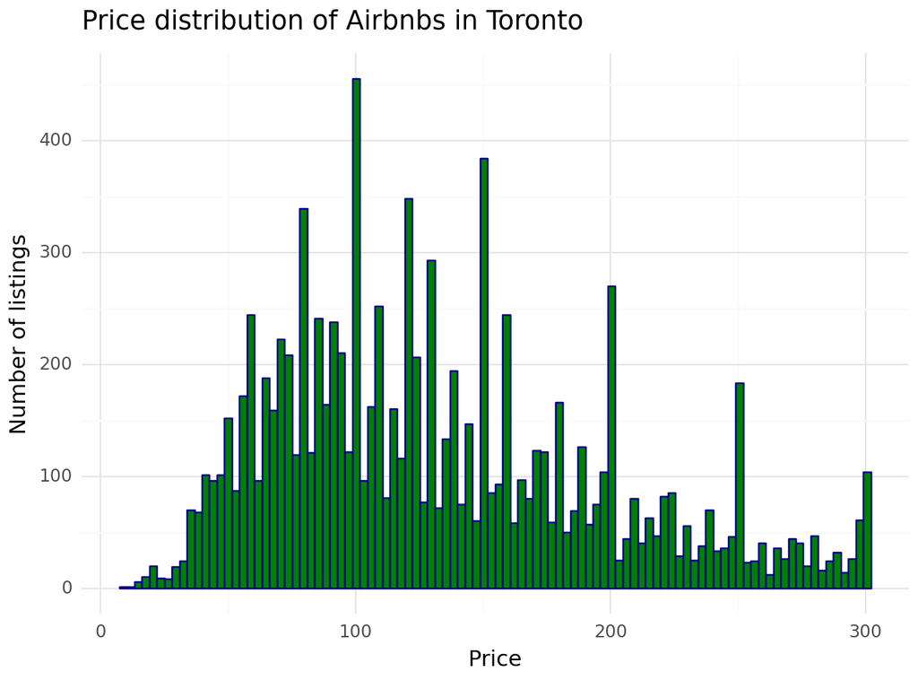

```
<Figure Size: (640 x 480)>
```

```python
# Checking the distribution of airbnb prices
ggplot(data, aes(x='usd_price_day')) + \
    geom_histogram(fill='green', color='darkblue', bins=100) + \
    theme_minimal() + \
    ggtitle('Price distribution of Airbnbs in Toronto') + \
    xlab('Price') + \
    ylab('Number of listings')
```

```python
# Taking a look at the average price by property and room type
data.groupby(["f_property_type", "f_room_type"]).agg(mean_price=("usd_price_day", np.mean))
```

| f_property_type | f_room_type | mean_price |
| --- | --- | --- |
| House | Entire/Apt | 156.060394 |
|  | Private | 82.692204 |
|  | Shared | 95.476190 |
| Rental Unit | Entire/Apt | 144.276187 |
|  | Private | 97.723658 |
|  | Shared | 75.950000 |

# Modelling

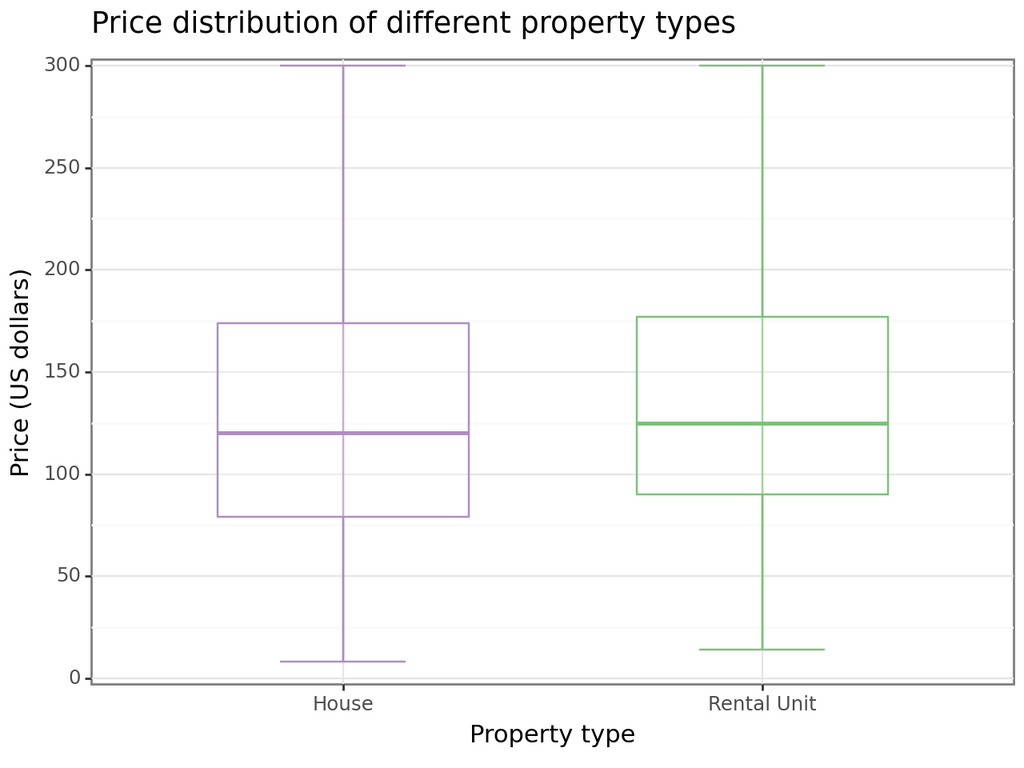

```
<Figure Size: (640 x 480)>
```

```python
# Creating a box plot groupped by property types
(
    ggplot(data, aes(x="f_property_type", y="usd_price_day"))
    + stat_boxplot(
        aes(group="f_property_type"),
        geom="errorbar",
        width=0.3,
        color=('#af8dc3', "#7fbf7b"),
        size=0.5,
        na_rm=True,
    )
    + geom_boxplot(
        aes(group="f_property_type"),
        color=('#af8dc3', "#7fbf7b"),
        size=0.5,
        width=0.6,
        alpha=0.3,
        na_rm=True,
        outlier_shape="",
    )
    + scale_y_continuous(expand=(0.01, 0.01), limits=(0, 300), breaks=seq(0, 301, 50))
    + labs(x="Property type", y="Price (US dollars)",
          title = "Price distribution of different property types")
    + theme_bw()
)
```

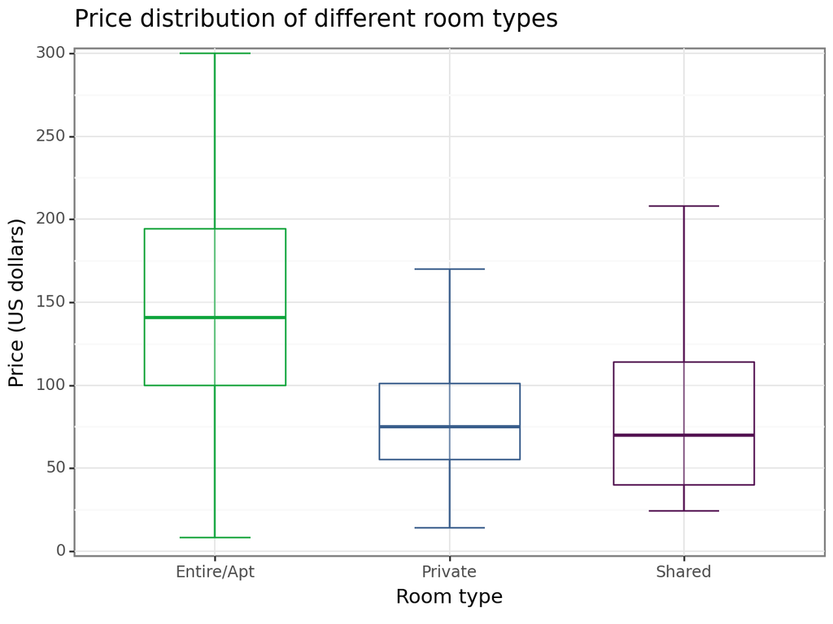

```
<Figure Size: (640 x 480)>
```

```python
# Creating a box plot groupped by room types
(
    ggplot(data, aes(x="f_room_type", y="usd_price_day"))
    + stat_boxplot(
        aes(group="f_room_type"),
        geom="errorbar",
        width=0.3,
        color=(color[1], color[0], color[2]),
        size=0.5,
        na_rm=True,
    )
    + geom_boxplot(
        aes(group="f_room_type"),
        color=(color[1], color[0], color[2]),
        size=0.5,
        width=0.6,
        alpha=0.3,
        na_rm=True,
        outlier_shape="",
    )
    + scale_y_continuous(expand=(0.01, 0.01), limits=(0, 300), breaks=seq(0, 301, 50))
    + labs(x="Room type", y="Price (US dollars)",
          title = "Price distribution of different room types")
    + theme_bw()
)
```

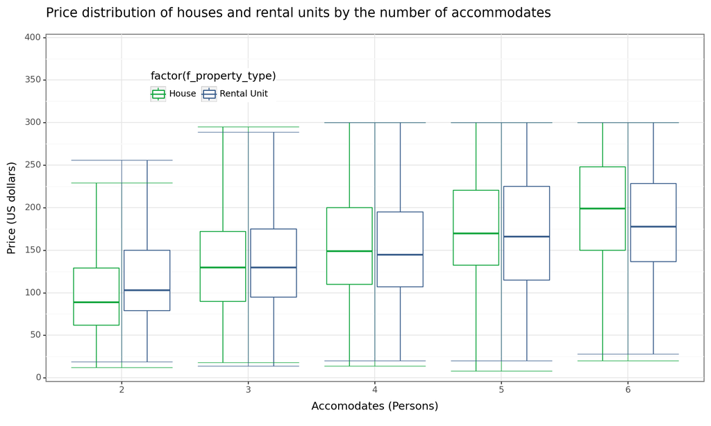

```
<Figure Size: (1000 x 600)>
```

```python
# Looking at the prices based on the number of accommodates
(
    ggplot(
        data,
        aes(
            x="factor(n_accommodates)",
            y="usd_price_day",
            color="factor(f_property_type)",
        ),

    )
    + geom_boxplot(alpha=0.8, na_rm=True, outlier_shape="", width=0.8, stat="boxplot")
    + stat_boxplot(geom="errorbar", width=0.8, size=0.3, na_rm=True)
    + scale_color_manual(name="", values=(color[1], color[0]))
    + scale_fill_manual(name="", values=(color[1], color[0]))
    + labs(x="Accomodates (Persons)", y="Price (US dollars)",
          title = "Price distribution of houses and rental units by the number of accommodates")
    + scale_y_continuous(expand=(0.01, 0.01), limits=(0, 400), breaks=seq(0, 401, 50))
    + theme_bw()
    + theme(legend_position=(0.3, 0.8), figure_size=(10, 6))
)
```

# 1. Model: OLS

#### Model 1. Regression of price on number of accommodates

$price=\beta_0 + \beta_1 accommodates$

- Building the models incrementally, I started with regressing the price on the number of guests.
- The R squared of the models increased gradually (from 0.183 to 0.391)
- Comparing the first regression to the other models in stargazer, it became visible that room types have a greater impact on the target variable.
- The comparison between OLS and Lowess uggested that the linear model could easily find a good fit.
- Despite the high BIC values moving around 113000, the RMSE of the models ranged between 50 and 59, with Model 4 fitting the data best among all the four models (50.559).

```python
# Creating the regression for Model 1
reg1 = smf.ols(formula="usd_price_day~n_accommodates", data=data).fit(cov_type="HC1")
```

## Linear (OLS) vs Non-linear (Lowess)

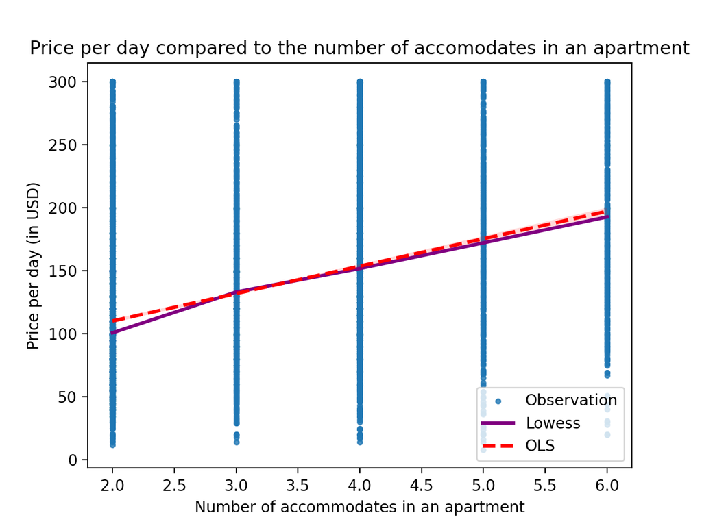

```python
# Plotting the OLS and Lowess models
sns.regplot(data, x = 'n_accommodates', y = 'usd_price_day', marker= '.', fit_reg= True, lowess= True, line_kws = {'color':'purple'})

# OLS
sns.regplot(data, x = 'n_accommodates', y = 'usd_price_day', scatter=False, line_kws={'color':'red', 'linestyle': '--'})

plt.title("Price per day compared to the number of accomodates in an apartment")
plt.xlabel('Number of accommodates in an apartment')
plt.ylabel('Price per day (in USD)')
plt.legend(['Observation', 'Lowess', 'OLS'])

plt.show()
```

The OLS and the Lowess plots are quite similar, therefore the linear model could easily find a good fit.

## Further models

#### Model 2. M1 + room types, property types, bathrooms, bedrooms, number of reviews

$price=\beta_0 + \beta_1 accommodates + \beta_2 roomtype + \beta_3 propertytype + \beta_4 bathroms + \beta_5 numberofbeds + \beta_6 numberofreviews$

#### Model 3. M2 + neighbourhood cleansed

$price=\beta_0 + \beta_1 accommodates + \beta_2 roomtype + \beta_3 propertytype + \beta_4 bathroms + \beta_5 numberofbeds + \beta_6 numberofreviews + \beta_7 neighbourhoodcleansed$

#### Model 4. M3 + several basic variables interactions

$price=\beta_0 + \beta_1 accommodates + \beta_2 roomtype + \beta_3 propertytype + \beta_4 bathroms + \beta_5 numberofbeds + \beta_6 numberofreviews + \beta_7 neighbourhoodcleansed + \beta_8 roomtype*propertytype + \beta_9 accommodates*propertype + \beta_10 roomtype * hasavailability + \beta_11 bathrooms*propertytype + \beta_12 neighbourhoodcleansed*propertytype + \beta_13 instantbookable*minimumnights$

```python
# Creating the regressions
reg2 = smf.ols(formula="usd_price_day~n_accommodates + f_room_type + f_property_type + f_bathrooms + n_beds + f_number_of_reviews", data=data).fit(cov_type="HC1")
reg3 = smf.ols(formula="usd_price_day~n_accommodates + f_room_type + f_property_type + f_bathrooms + n_beds + f_number_of_reviews + f_neighbourhood_cleansed", data=data).fit(cov_type="HC1")
reg4 = smf.ols(formula="usd_price_day~n_accommodates + f_room_type + f_property_type + f_neighbourhood_cleansed + f_bathrooms + n_beds + f_number_of_reviews + f_room_type*f_property_type + n_accommodates*f_property_type + f_room_type*d_has_availability + f_bathrooms*f_property_type + f_neighbourhood_cleansed*f_property_type + d_instant_bookable*f_minimum_nights", data=data).fit(cov_type="HC1")
```

```python
# Viewing regression results with stargazer
sg = stargazer.Stargazer([reg1, reg2, reg3, reg4])
covariate_order = ["n_accommodates","f_room_type[T.Private]", "f_room_type[T.Shared]", "f_property_type[T.Rental Unit]",
                    "f_bathrooms[T.1]", "f_bathrooms[T.2]", "n_beds",
                   "f_number_of_reviews[T.1]", "f_number_of_reviews[T.2]", "Intercept"]

# Set covariate order
sg.covariate_order(covariate_order)

# Rename covariates
sg.rename_covariates({"n_accommodates": "Accommodates",
                      "f_room_type[T.Private]": "Private Room Type",
                      "f_room_type[T.Shared]": "Shared Room Type",
                      "f_property_type[T.Rental Unit]": "Rental Unit",
                      "f_bathrooms[T.1]" : "Bathrooms (1)",
                      "f_bathrooms[T.2]" : "Bathrooms (2-10)",
                      "n_beds" : "Beds",
                      "f_number_of_reviews[T.1]" : "Number of reviews (<27)",
                      "f_number_of_reviews[T.2]" : "Number of reviews (27<)",
                      "Intercept": "Constant"})

# Adding RMSE for measurement in the full sample for each model
rmse_values = [round(rmse(x.fittedvalues, data.usd_price_day), 3) for x in [reg1, reg2, reg3, reg4]]
sg.add_line('RMSE', rmse_values, location=stargazer.LineLocation.FOOTER_BOTTOM)

# Adding BIC for measurement in the full sample for each model
bic = [round(x.bic, 2) for x in [reg1, reg2, reg3, reg4]]
sg.add_line('BIC', bic, location=stargazer.LineLocation.FOOTER_BOTTOM)

# Display Stargazer table
sg
```

|  | *Dependent variable: usd_price_day* |  |  |  |
| --- | --- | --- | --- | --- |
|  | (1) | (2) | (3) | (4) |
| Accommodates | 21.746*** | 12.599*** | 12.989*** | 14.479*** |
|  | (0.466) | (0.699) | (0.700) | (0.813) |
| Private Room Type |  | -50.939*** | -35.986*** | -54.642*** |
|  |  | (1.229) | (1.326) | (13.401) |
| Shared Room Type |  | -54.936*** | -43.116*** | -62.135*** |
|  |  | (9.409) | (9.143) | (12.911) |
| Rental Unit |  | -2.250* | -5.085*** | -11.723 |
|  |  | (1.194) | (1.194) | (30.255) |
| Bathrooms (1) |  | 8.179 | 7.049 | -1.317 |
|  |  | (17.376) | (15.586) | (21.187) |
| Bathrooms (2-10) |  | 26.580 | 22.227 | 10.184 |
|  |  | (17.435) | (15.656) | (21.276) |
| Beds |  | 1.887** | 3.495*** | 2.707*** |
|  |  | (0.936) | (0.934) | (0.930) |
| Number of reviews (<27) |  | 3.577*** | 2.834** | 0.359 |
|  |  | (1.296) | (1.289) | (1.311) |
| Number of reviews (27<) |  | 7.393*** | 4.261*** | 0.469 |
|  |  | (1.489) | (1.487) | (1.528) |
| Constant | 66.609*** | 91.315*** | 54.368*** | 82.543*** |
|  | (1.489) | (17.512) | (16.754) | (24.952) |
| Observations | 10376 | 10376 | 10376 | 10376 |
| R<sup>2</sup> | 0.183 | 0.298 | 0.353 | 0.391 |
| Adjusted R<sup>2</sup> | 0.183 | 0.297 | 0.343 | 0.373 |
| Residual Std. Error | 58.572 (df=10374) | 54.333 (df=10366) | 52.523 (df=10227) | 51.301 (df=10078) |
| F Statistic | 2176.973*** (df=1; 10374) | 594.167*** (df=9; 10366) | 51.802*** (df=148; 10227) | 78.584*** (df=297; 10078) |
| RMSE | 58.566 | 54.307 | 52.145 | 50.559 |
| BIC | 113928.12 | 112435.18 | 112877.6 | 113614.69 |
| Note: | *p<0.1; **p<0.05; ***p<0.01 |  |  |  |

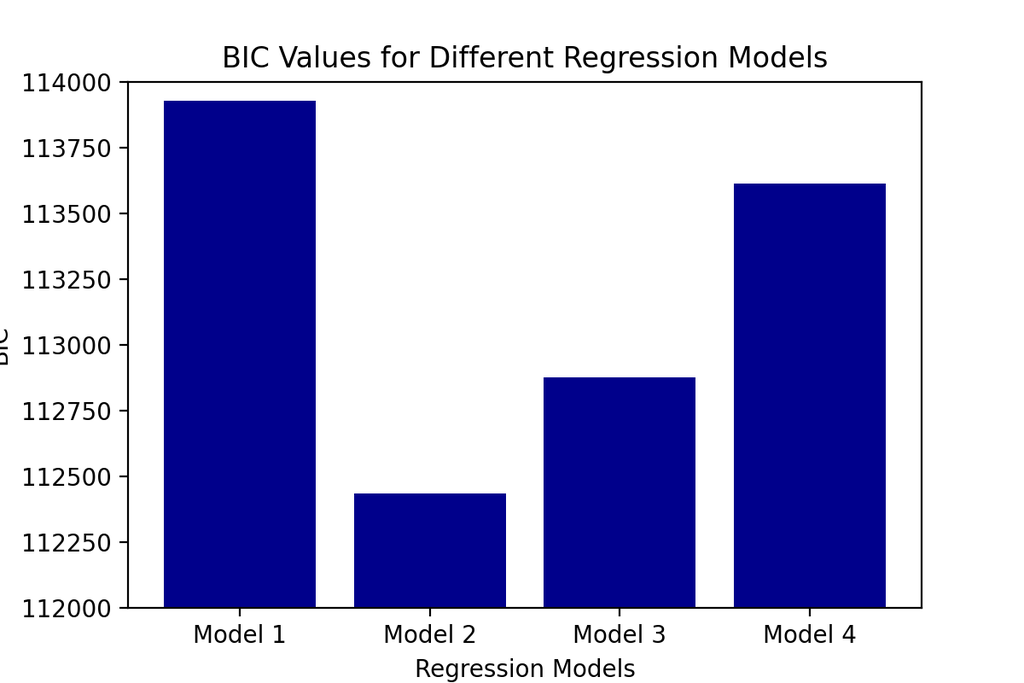

```python
# Plotting a bar chart to visualize the differences in BIC scores
bic_values = [reg1.bic, reg2.bic, reg3.bic, reg4.bic]

# Model names as labels
model_names = ['Model 1', 'Model 2', 'Model 3', 'Model 4']

# Customizing the bar chart
plt.figure(figsize=(6, 4))
plt.bar(model_names, bic_values, color='darkblue')

# Adjusting and giving a limited interval for the y axis to see the slight differences between the scores
plt.ylim(112000, 114000)
plt.title('BIC Values for Different Regression Models')
plt.xlabel('Regression Models')
plt.ylabel('BIC')
plt.show()
```

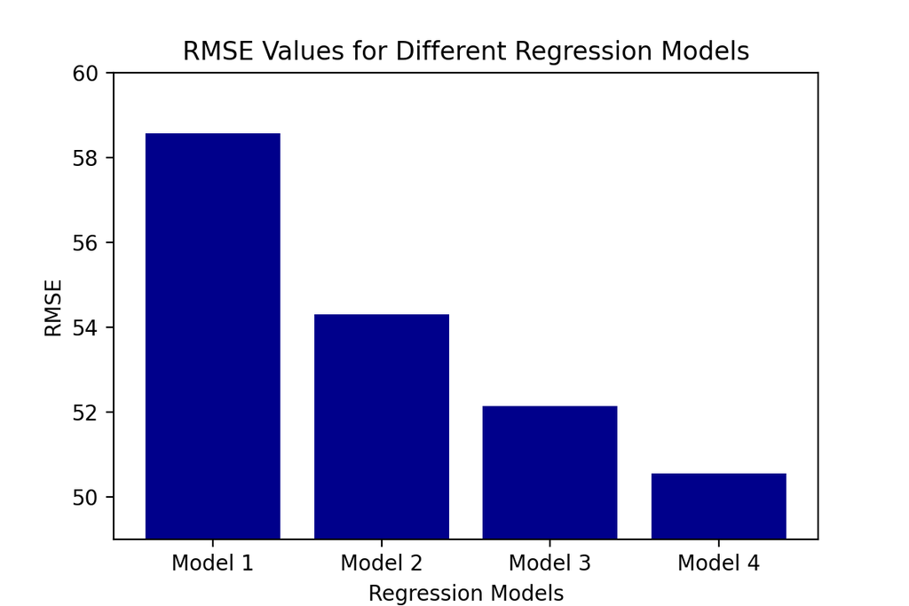

```python
# Plotting a bar chart to visualize the differences in RMSE scores
rmse_values = [rmse(reg1.fittedvalues,data.usd_price_day),
               rmse(reg2.fittedvalues,data.usd_price_day),
               rmse(reg3.fittedvalues,data.usd_price_day),
               rmse(reg4.fittedvalues,data.usd_price_day)]

# Model names as labels
model_names = ['Model 1', 'Model 2', 'Model 3', 'Model 4']

# Customizing the bar chart
plt.figure(figsize=(6, 4))
plt.bar(model_names, rmse_values, color='darkblue')

# Adjusting and giving a limited interval for the y axis to see the slight differences between the scores
plt.ylim(49, 60)
plt.title('RMSE Values for Different Regression Models')
plt.xlabel('Regression Models')
plt.ylabel('RMSE')
plt.show()
```

# 2. Model: LASSO

```python
# Defining variables

data['n_accommodates2'] = data['n_accommodates']**2
data['n_beds2'] = data['n_beds']**2
data['n_beds3'] = data['n_beds']**3

basic_lev = (
    "n_accommodates",
    "n_beds",
    "f_property_type",
    "f_room_type",
)
basic_add = ("f_bathrooms", "f_minimum_nights")
reviews = ("f_number_of_reviews", "n_review_scores_rating")
poly_lev = ("n_accommodates2", "n_beds2", "n_beds3")
```

#### Regressions with cross-validation

```python
# Defining different sets of features
X1 = ("f_room_type*f_property_type", "f_room_type*d_host_is_superhost")
X2 = ("d_instant_bookable*f_property_type", "d_has_availability*f_property_type", "d_host_is_superhost*f_property_type")
X3 = ("(f_property_type + f_room_type + f_minimum_nights + n_beds)*d_host_is_superhost")
```

```python
# Creating 8 different models
modellev1="~ n_accommodates"
modellev2="~"+"+".join(basic_lev)
modellev3="~"+"+".join(basic_lev)+"+"+"+".join(basic_add)+"+"+"+".join(reviews)
modellev4="~"+"+".join(basic_lev)+"+"+"+".join(basic_add)+"+"+"+".join(reviews)+"+"+"+".join(poly_lev)
modellev5="~"+"+".join(basic_lev)+"+"+"+".join(basic_add)+"+"+"+".join(reviews)+"+"+"+".join(poly_lev)+"+"+"+".join(X1)
modellev6="~"+"+".join(basic_lev)+"+"+"+".join(basic_add)+"+"+"+".join(reviews)+"+"+"+".join(poly_lev)+"+"+"+".join(X1)+"+"+"+".join(X2)
modellev7="~"+"+".join(basic_lev)+"+"+"+".join(basic_add)+"+"+"+".join(reviews)+"+"+"+".join(poly_lev)+"+"+"+".join(X1)+"+"+"+".join(X2)
modellev8="~"+"+".join(basic_lev)+"+"+"+".join(basic_add)+"+"+"+".join(reviews)+"+"+"+".join(poly_lev)+"+"+"+".join(X1)+"+"+"+".join(X2)+"+"+X3
```

```python
# Set the seed to make results reproducable
np.random.seed(20240115)
```

```python
# Splitting the train and hold out set
data_work,data_holdout=train_test_split(data, test_size=smp_size)
```

```python
# Checking the shape of the sets
print(data_work.shape)
print(data_holdout.shape)
```

```
(8302, 68)
(2074, 68)
```

```python
# Setting the n folds to 5
n_folds=5
```

```python
# Splitting the data into 4 categories, assuming that the data is randomly ordered
k = KFold(n_splits=4, shuffle=False, random_state=None)
```

```python
def cv_reg(formula, data, kfold, testdata, robustse=None):
    regression_list = []
    predicts_on_test = []
    rsquared = []
    rmse_list = []
    rmse_list_test = []

    # Calculating OLS for each fold

    for train_index, test_index in k.split(data):
        data_train, data_test = data.iloc[train_index, :], data.iloc[test_index, :]
        if robustse is None:
            model = smf.ols(formula, data=data_train).fit()
        else:
            model = smf.ols(formula, data=data_train).fit(cov_type=robustse)
        regression_list += [model]
        predicts_on_test += [model.predict(data_test)]
        rsquared += [model.rsquared]

        rmse_tr = pd.concat(
            [data_train["usd_price_day"], model.predict(data_train)],
            axis=1,
            keys=["usd_price_day", "predicted"],
        )
        rmse_tr = rmse_tr[~rmse_tr.isna().any(axis=1)]

        rmse_te = pd.concat(
            [data_test["usd_price_day"], model.predict(data_test)],
            axis=1,
            keys=["usd_price_day", "predicted"],
        )
        rmse_te = rmse_te[~rmse_te.isna().any(axis=1)]

        rmse_list += [rmse(rmse_tr["usd_price_day"], rmse_tr["predicted"], axis=0)]
        rmse_list_test += [rmse(rmse_te["usd_price_day"], rmse_te["predicted"], axis=0)]
    nvars = model.df_model

    # We return a dictionary with the
    return {
        "regressions": regression_list,
        "test_predict": predicts_on_test,
        "r2": rsquared,
        "rmse": rmse_list,
        "rmse_test": rmse_list_test,
        "nvars": nvars,
    }

# Summarize method --> gives us a df
def summarize_cv(cvlist, stat="rmse"):
    result = pd.DataFrame(
        {"Model" + str(x + 1): cvlist[x][stat] for x in range(len(cvlist))}
    )
    result["Resample"] = ["Fold" + str(x + 1) for x in range(len(cvlist[0]["rmse"]))]
    result = result.set_index("Resample")
    result = pd.concat([result, pd.DataFrame(result.mean(), columns=["Average"]).T])
    return result
```

```python
# Performing cross-validated linear regressions with cov.type = HC0
cv_list = []
for i in [
    modellev1,
    modellev2,
    modellev3,
    modellev4,
    modellev5,
    modellev6,
    modellev7,
    modellev8,
]:
    cv_list += [cv_reg("usd_price_day" + i, data, k, "HC0")]
```

```python
# Summarizing the cross-validation results
summarize_cv(cv_list)
```

|  | Model1 | Model2 | Model3 | Model4 | Model5 | Model6 | Model7 | Model8 |
| --- | --- | --- | --- | --- | --- | --- | --- | --- |
| Fold1 | 59.019909 | 55.277836 | 53.825673 | 53.807415 | 53.608347 | 53.573334 | 53.573334 | 53.552427 |
| Fold2 | 58.445551 | 54.495450 | 53.175291 | 53.155809 | 52.986181 | 52.970297 | 52.970297 | 52.898318 |
| Fold3 | 58.007776 | 54.323493 | 52.933759 | 52.921403 | 52.692071 | 52.676163 | 52.676163 | 52.602858 |
| Fold4 | 58.769452 | 54.593604 | 53.351122 | 53.340250 | 53.267597 | 53.247659 | 53.247659 | 53.167482 |
| Average | 58.560672 | 54.672596 | 53.321461 | 53.306219 | 53.138549 | 53.116863 | 53.116863 | 53.055271 |

```python
# Creating a DataFrame for the RMSE values of the train and the test set
rmse_levels = {"nvars": [], "var": [], "value": []}
for i in range(0, 8):
    rmse_levels["nvars"].append(int(cv_list[i]["nvars"]))
    rmse_levels["var"].append("RMSE Training")
    rmse_levels["value"].append(pd.Series(cv_list[i]["rmse"]).mean())
for i in range(0, 8):
    rmse_levels["nvars"].append(int(cv_list[i]["nvars"]))
    rmse_levels["var"].append("RMSE Test")
    rmse_levels["value"].append(pd.Series(cv_list[i]["rmse_test"]).mean())
rmse_levels = pd.DataFrame.from_dict(rmse_levels)
rmse_levels["nvars2"] = rmse_levels["nvars"] + 1
```

```python
rmse_levels
```

|  | nvars | var | value | nvars2 |
| --- | --- | --- | --- | --- |
| 0 | 1 | RMSE Training | 58.560672 | 2 |
| 1 | 5 | RMSE Training | 54.672596 | 6 |
| 2 | 12 | RMSE Training | 53.321461 | 13 |
| 3 | 15 | RMSE Training | 53.306219 | 16 |
| 4 | 20 | RMSE Training | 53.138549 | 21 |
| 5 | 25 | RMSE Training | 53.116863 | 26 |
| 6 | 25 | RMSE Training | 53.116863 | 26 |
| 7 | 28 | RMSE Training | 53.055271 | 29 |
| 8 | 1 | RMSE Test | 58.583176 | 2 |
| 9 | 5 | RMSE Test | 54.726030 | 6 |
| 10 | 12 | RMSE Test | 53.413801 | 13 |
| 11 | 15 | RMSE Test | 53.423202 | 16 |
| 12 | 20 | RMSE Test | 53.368275 | 21 |
| 13 | 25 | RMSE Test | 53.385132 | 26 |
| 14 | 25 | RMSE Test | 53.385132 | 26 |
| 15 | 28 | RMSE Test | 53.384475 | 29 |

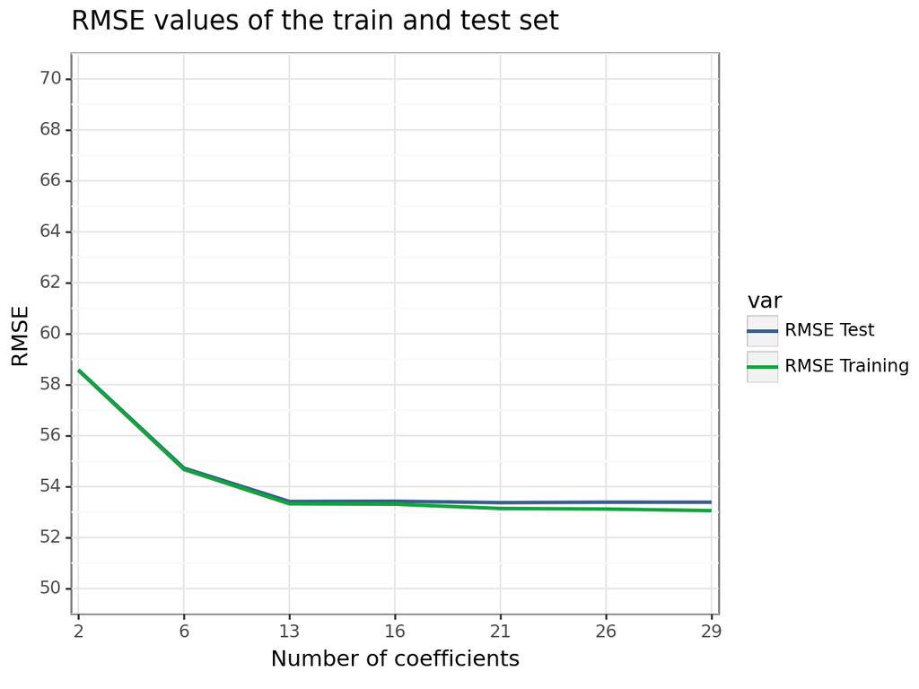

```
<Figure Size: (640 x 480)>
```

```python
# Visualizing the RMSE values of the train and the test set
(
    ggplot(rmse_levels, aes(x="factor(nvars2)", y="value", color="var", group="var"))
    + geom_line(size=1, show_legend=True, na_rm=True)
    + scale_color_manual(name="", values=(color[0], color[1]))
    + scale_y_continuous(name="RMSE", limits=(50, 70), breaks=seq(50, 70, 2))
    + scale_x_discrete(
        name="Number of coefficients",
        expand=(0.01, 0.01)
    )
        + labs(title = "RMSE values of the train and test set")
    + theme_bw()
)
```

Despite the good performance, further analysis and evaluation are needed to determine the best model for the specific context and requirements.

#### Doing LASSO in another way to check out lambda values

```python
# Defining the model evaluation method and splitting the dataset into 5 folds
cv = RepeatedKFold(n_splits=5, n_repeats=1, random_state=1)
y, X = patsy.dmatrices("usd_price_day" + modellev8, data)
```

```python
# Scaling the data
scaler = StandardScaler()
X = scaler.fit_transform(X)

# Preparing for Ridge regression with cross-validation
X_train, X_test, y_train, y_test = train_test_split(
    X, y, test_size=smp_size, random_state=10
)

# Defining a range of lambda values
lambdas = [i/100 for i in range(5, 100,5)]

# Creating arrays to store R-squared values
train_r_squared = np.zeros(len(lambdas))
test_r_squared = np.zeros(len(lambdas))

pred_num = X.shape[1]
coeff_a = np.zeros((len(lambdas), pred_num))
```

```python
import datetime
from sklearn.model_selection import cross_val_score

for ind, i in enumerate(lambdas):
    print(f"Run: {str(ind).rjust(2)}, lambda: {i:.2f}, start: {datetime.datetime.now().strftime('%Y-%m-%d %H:%M:%S')}")

    reg = Lasso(alpha = i, random_state= 20240211)
    reg.fit(X_train, y_train)
    results = cross_val_score(reg, X, y, cv=cv, scoring="r2")

    train_r_squared[ind] = reg.score(X_train, y_train)
    test_r_squared[ind] = reg.score(X_test, y_test)
```

```
Run:  0, lambda: 0.05, start: 2024-02-11 16:24:07
Run:  1, lambda: 0.10, start: 2024-02-11 16:24:08
Run:  2, lambda: 0.15, start: 2024-02-11 16:24:08
Run:  3, lambda: 0.20, start: 2024-02-11 16:24:08
Run:  4, lambda: 0.25, start: 2024-02-11 16:24:08
Run:  5, lambda: 0.30, start: 2024-02-11 16:24:08
Run:  6, lambda: 0.35, start: 2024-02-11 16:24:09
Run:  7, lambda: 0.40, start: 2024-02-11 16:24:09
Run:  8, lambda: 0.45, start: 2024-02-11 16:24:09
Run:  9, lambda: 0.50, start: 2024-02-11 16:24:09
Run: 10, lambda: 0.55, start: 2024-02-11 16:24:09
Run: 11, lambda: 0.60, start: 2024-02-11 16:24:10
Run: 12, lambda: 0.65, start: 2024-02-11 16:24:10
Run: 13, lambda: 0.70, start: 2024-02-11 16:24:10
Run: 14, lambda: 0.75, start: 2024-02-11 16:24:11
Run: 15, lambda: 0.80, start: 2024-02-11 16:24:11
Run: 16, lambda: 0.85, start: 2024-02-11 16:24:11
Run: 17, lambda: 0.90, start: 2024-02-11 16:24:11
Run: 18, lambda: 0.95, start: 2024-02-11 16:24:12
```

```python
# Melting the R-squared data into a DataFrame
r_squared_data = (
    pd.DataFrame(
        {
            "$R^2$ Test set": test_r_squared,
            "$R^2$ Training set": train_r_squared,
            "lambda": lambdas,
        }
    )
    .melt(id_vars=["lambda"])
)
```

```python
# Transforming the variables into categorical and reordering
r_squared_data["variable"] = r_squared_data["variable"].astype("category").cat.reorder_categories(
    ["$R^2$ Training set", "$R^2$ Test set"]
)
```

```python
r_squared_data
```

|  | lambda | variable | value |
| --- | --- | --- | --- |
| 0 | 0.05 | $R^2$ Test set | 0.301345 |
| 1 | 0.10 | $R^2$ Test set | 0.301868 |
| 2 | 0.15 | $R^2$ Test set | 0.302269 |
| 3 | 0.20 | $R^2$ Test set | 0.302291 |
| 4 | 0.25 | $R^2$ Test set | 0.302168 |
| 5 | 0.30 | $R^2$ Test set | 0.301967 |
| 6 | 0.35 | $R^2$ Test set | 0.301712 |
| 7 | 0.40 | $R^2$ Test set | 0.301633 |
| 8 | 0.45 | $R^2$ Test set | 0.301451 |
| 9 | 0.50 | $R^2$ Test set | 0.301212 |
| 10 | 0.55 | $R^2$ Test set | 0.300970 |
| 11 | 0.60 | $R^2$ Test set | 0.300755 |
| 12 | 0.65 | $R^2$ Test set | 0.300537 |
| 13 | 0.70 | $R^2$ Test set | 0.300308 |
| 14 | 0.75 | $R^2$ Test set | 0.300064 |
| 15 | 0.80 | $R^2$ Test set | 0.299804 |
| 16 | 0.85 | $R^2$ Test set | 0.299530 |
| 17 | 0.90 | $R^2$ Test set | 0.299243 |
| 18 | 0.95 | $R^2$ Test set | 0.298969 |
| 19 | 0.05 | $R^2$ Training set | 0.338407 |
| 20 | 0.10 | $R^2$ Training set | 0.338318 |
| 21 | 0.15 | $R^2$ Training set | 0.338180 |
| 22 | 0.20 | $R^2$ Training set | 0.338003 |
| 23 | 0.25 | $R^2$ Training set | 0.337783 |
| 24 | 0.30 | $R^2$ Training set | 0.337515 |
| 25 | 0.35 | $R^2$ Training set | 0.337206 |
| 26 | 0.40 | $R^2$ Training set | 0.336945 |
| 27 | 0.45 | $R^2$ Training set | 0.336709 |
| 28 | 0.50 | $R^2$ Training set | 0.336523 |
| 29 | 0.55 | $R^2$ Training set | 0.336326 |
| 30 | 0.60 | $R^2$ Training set | 0.336144 |
| 31 | 0.65 | $R^2$ Training set | 0.335953 |
| 32 | 0.70 | $R^2$ Training set | 0.335748 |
| 33 | 0.75 | $R^2$ Training set | 0.335528 |
| 34 | 0.80 | $R^2$ Training set | 0.335293 |
| 35 | 0.85 | $R^2$ Training set | 0.335042 |
| 36 | 0.90 | $R^2$ Training set | 0.334778 |
| 37 | 0.95 | $R^2$ Training set | 0.334514 |

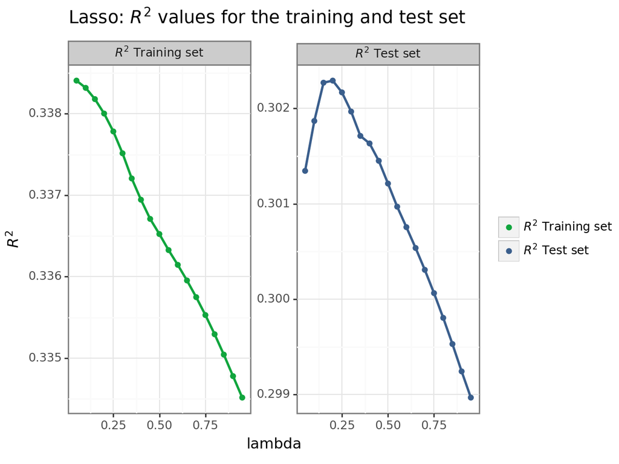

```
<Figure Size: (640 x 480)>
```

```python
# Plotting the R2 results
(
    ggplot(r_squared_data, aes(x="lambda", y="value", color="variable"))
    + geom_point()
    + geom_line(size=1, show_legend=False, na_rm=True)
    + scale_color_manual(name="", values=(color[1], color[0]))
    + scale_y_continuous(name="$R^2$")
    + facet_wrap("variable", scales="free")
    + theme_bw()
    + theme(subplots_adjust={"wspace": 0.25},legend_title=element_blank())
    + labs(title = 'Lasso: $R^2$ values for the training and test set')
)
```

Separating the $R^2$ values gave us another perspective on fit and model performance. Similar to the other LASSO results, the values indicate that the model is fitting well to both data sets. The values for the training set are consistently higher, suggesting that the model might be overfitting to some extent, as it performs better on the data it was trained on compared to the unseen data.

```python
# Checking the R-squared values converted to percentages for different lambda values
df_lam = pd.DataFrame(test_r_squared*100, columns=['R_squared'])
df_lam['lambda'] = (lambdas)
df_lam.loc[df_lam['R_squared'].idxmax()]
```

```
R_squared    30.229122
lambda        0.200000
Name: 3, dtype: float64
```

```python
# Finding the best fit
reg_best = Lasso(alpha = df_lam.loc[df_lam['R_squared'].idxmax()]['lambda'])
reg_best.fit(X_train, y_train)
```

```
Lasso(alpha=0.2)
```

```python
# Examining the coefficients of our model
reg_best.coef_[reg_best.coef_>0]
```

```
array([ 5.95581975,  5.93928424,  3.42372548, 14.20454183,  3.11597296,
        2.46385876,  1.85805046,  0.75657732,  0.25623617])
```

```python
# Checking out the parameters of the most optimal lambda
reg_best.get_params()
```

```
{'alpha': 0.2,
 'copy_X': True,
 'fit_intercept': True,
 'max_iter': 1000,
 'positive': False,
 'precompute': False,
 'random_state': None,
 'selection': 'cyclic',
 'tol': 0.0001,
 'warm_start': False}
```

#### Diagnostics for LASSO

```python
# Fitting OLS regression models with modellev as the predictor variables,
model3_level = smf.ols('usd_price_day'+modellev3, data=data_work).fit(cov_type='HC0')
model7_level = smf.ols('usd_price_day'+modellev7, data=data_work).fit(cov_type='HC0')
```

```python
# Looking at the holdout RMSE
model3_level_work_predictions = pd.concat(
    [data_work["usd_price_day"], model3_level.predict(data_work)],
    axis=1,
    keys=["price", "predicted"],
)
```

```python
model3_level_work_predictions.tail()
```

|  | price | predicted |
| --- | --- | --- |
| 19333 | 99.0 | NaN |
| 6037 | 111.0 | NaN |
| 4206 | 115.0 | 133.991402 |
| 18543 | 75.0 | 125.597419 |
| 17211 | 25.0 | 75.759865 |

```python
# Filtering out the NA values
model3_level_work_predictions = model3_level_work_predictions[~model3_level_work_predictions.isna().any(axis=1)]
model3_level_work_rmse = rmse(model3_level_work_predictions["price"], model3_level_work_predictions["predicted"], axis=0)
```

```python
# Checking the RMSE of the work set
model3_level_work_rmse
```

```
53.48362138987727
```

```python
# Comparing the RMSE values of the work and holdout set
model3_level_holdout_predictions = pd.concat(
    [data_holdout["usd_price_day"], model3_level.predict(data_holdout)],
    axis=1,
    keys=["price", "predicted"],
)
model3_level_holdout_predictions = model3_level_holdout_predictions[~model3_level_holdout_predictions.isna().any(axis=1)]
model3_level_holdout_rmse = rmse(model3_level_holdout_predictions["price"], model3_level_holdout_predictions["predicted"], axis=0)
print(
    f"RMSE work:{round(model3_level_work_rmse,2)}",
    "\t",
    f"RMSE holdout:{model3_level_holdout_rmse:.2f}",
)
```

```
RMSE work:53.48 	 RMSE holdout:52.81
```

#### Charting the fitted vs the actual values

```python
# Calculating statistics for the daily price
Ylev=data_holdout['usd_price_day']
meanY=Ylev.mean()
sdY=Ylev.std()
meanY_m2SE = meanY -1.96 * sdY
meanY_p2SE = meanY + 1.96 * sdY
Y5p=Ylev.quantile(.05)
Y95p=Ylev.quantile(.95)
```

```python
# Getting the prediction
model3_level.get_prediction(data_holdout).summary_frame(alpha=0.05)
```

|  | mean | mean_se | mean_ci_lower | mean_ci_upper | obs_ci_lower | obs_ci_upper |
| --- | --- | --- | --- | --- | --- | --- |
| 0 | 155.592976 | 1.663960 | 152.331674 | 158.854278 | 50.605515 | 260.580437 |
| 1 | 86.749497 | 1.612438 | 83.589177 | 89.909817 | -18.234876 | 191.733870 |
| 2 | 143.242865 | 1.388036 | 140.522365 | 145.963366 | 38.270812 | 248.214919 |
| 3 | 129.935428 | 1.682795 | 126.637210 | 133.233646 | 24.946814 | 234.924043 |
| 4 | 134.380214 | 2.265919 | 129.939094 | 138.821335 | 29.349483 | 239.410946 |
| ... | ... | ... | ... | ... | ... | ... |
| 1535 | 106.209598 | 2.482717 | 101.343563 | 111.075633 | 1.160042 | 211.259154 |
| 1536 | 82.497391 | 1.723603 | 79.119191 | 85.875591 | -22.493767 | 187.488548 |
| 1537 | 121.709290 | 1.596935 | 118.579354 | 124.839226 | 16.725828 | 226.692753 |
| 1538 | 80.919586 | 2.196742 | 76.614051 | 85.225121 | -24.105499 | 185.944672 |
| 1539 | 180.318263 | 2.943834 | 174.548454 | 186.088071 | 75.222965 | 285.413560 |

1540 rows × 6 columns

```python
# Create data frame with the actual and predicted values
data_diagnostic = model3_level.get_prediction(data_holdout).summary_frame(alpha=0.05)

df_ = pd.concat(
    [data_holdout["usd_price_day"], model3_level.predict(data_holdout)],
    axis=1,
    keys=["price", "predicted"],
)
```

```python
# Looking for Na values
df_.isna().sum()
```

```
price          0
predicted    534
dtype: int64
```

```python
# Returning whether any element is non-zero or empty
df_ = df_[~df_.isna().any(axis=1)].reset_index(drop=True)
data_diagnostic["Ylev"] = df_["price"]
```

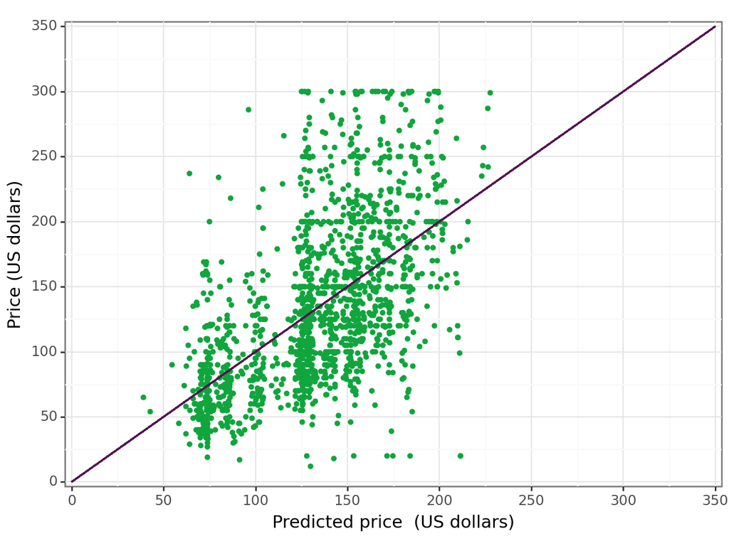

```
<Figure Size: (640 x 480)>
```

```python
# Plotting the actual vs predicted values
(
    ggplot(data=data_diagnostic)
    + geom_point(
        aes(y="Ylev", x="mean"),
        color=color[1],
        size=1,
        alpha=0.7,
        show_legend=False,
        na_rm=True,
    )
    + geom_segment(aes(x=0, y=0, xend=350, yend=350), size=0.5, color=color[2])
    + coord_cartesian(xlim=(0, 350), ylim=(0, 350))
    + scale_x_continuous(
        expand=(0.01, 0.01), limits=(0, 350), breaks=seq(0, 350, by=50)
    )
    + scale_y_continuous(
        expand=(0.01, 0.01), limits=(0, 350), breaks=seq(0, 350, by=50)
    )
    + labs(y="Price (US dollars)", x="Predicted price  (US dollars)")
    + theme_bw()
)
```

# 3. Model: Random Forest

```python
# Setting the train and hold out set
data_train, data_holdout = train_test_split( data, train_size=0.7, random_state=42)
```

```python
# Checking the shape of the train set and hold out set
data_train.shape, data_holdout.shape
```

```
((7263, 68), (3113, 68))
```

```python
# Creating a list for basic variables
basic_vars = [
    "n_accommodates",
    "n_beds",
    "f_property_type",
    "f_room_type",
    "f_bathrooms",
    "f_minimum_nights",
    "n_maximum_nights",
    "f_neighbourhood_cleansed",
]

# Creating a list for reviews variables
reviews = [
    "f_number_of_reviews",
    "n_review_scores_rating",
    "n_reviews_per_month",
]

# Creating amenities from the dummy variables
amenities = [col for col in data if col.startswith("d_")]
```

```python
amenities
```

```
['d_host_is_superhost',
 'd_host_has_profile_pic',
 'd_host_identity_verified',
 'd_has_availability',
 'd_instant_bookable']
```

```python
# Creating interactions for LASSO
X1 = [
    "n_accommodates:f_property_type",
    "f_room_type:f_property_type",
    "f_room_type:d_has_availability",
    "f_bathrooms:f_property_type",
    "f_neighbourhood_cleansed:f_property_type",
    "d_instant_bookable:f_minimum_nights",
]
# with boroughs
X2 = [
    "f_property_type:f_neighbourhood_cleansed",
    "f_room_type:f_neighbourhood_cleansed",
    "n_accommodates:f_neighbourhood_cleansed",
]
```

```python
# Creating different predictors, including the basic variables, amenities and the interaction terms
predictors_1 = basic_vars
predictors_2 = basic_vars + reviews + amenities
predictors_E = basic_vars + reviews + amenities + X1 + X2
```

```python
# Creating the design matrices that represents the predictors_2 and the target variable in a structured format
y, X = dmatrices("usd_price_day ~ " + " + ".join(predictors_2), data_train)
```

```python
# Calculating the optimal number of variables (the square root of the number of variables we obtain)
print('The theoretical recommended number of variables: {:.2f}.'.format(math.sqrt(len(X.design_info.column_names))))
```

```
The theoretical recommended number of variables: 12.61.
```

```python
# Creating a GridSearch
rfr = RandomForestRegressor(random_state = 20240211)
```

```python
# Searching for every potential parameter
tune_grid = {"max_features": [6, 8, 10, 12], "min_samples_leaf": [5, 10, 15]}
```

```python
# Using GridSearch to tune hyperparameters of an estimator and find the best combination of parameter values
rf_random = GridSearchCV(
    rfr,
    tune_grid,
    cv=5,
    scoring="neg_root_mean_squared_error",
    verbose=3,
)
```

```python
%%time

# Triggering the GridSearch process
# Evaluating different combinations of hyperparameters using CV
rf_model = rf_random.fit(X, y.ravel())
```

```
Fitting 5 folds for each of 12 candidates, totalling 60 fits
[CV 1/5] END max_features=6, min_samples_leaf=5;, score=-55.547 total time=   0.6s
[CV 2/5] END max_features=6, min_samples_leaf=5;, score=-54.419 total time=   0.4s
[CV 3/5] END max_features=6, min_samples_leaf=5;, score=-53.487 total time=   0.2s
[CV 4/5] END max_features=6, min_samples_leaf=5;, score=-53.163 total time=   0.2s
[CV 5/5] END max_features=6, min_samples_leaf=5;, score=-56.308 total time=   0.3s
[CV 1/5] END max_features=6, min_samples_leaf=10;, score=-57.650 total time=   0.2s
[CV 2/5] END max_features=6, min_samples_leaf=10;, score=-56.612 total time=   0.2s
[CV 3/5] END max_features=6, min_samples_leaf=10;, score=-55.577 total time=   0.2s
[CV 4/5] END max_features=6, min_samples_leaf=10;, score=-55.671 total time=   0.2s
[CV 5/5] END max_features=6, min_samples_leaf=10;, score=-58.304 total time=   0.2s
[CV 1/5] END max_features=6, min_samples_leaf=15;, score=-59.427 total time=   0.1s
[CV 2/5] END max_features=6, min_samples_leaf=15;, score=-58.351 total time=   0.2s
[CV 3/5] END max_features=6, min_samples_leaf=15;, score=-57.062 total time=   0.1s
[CV 4/5] END max_features=6, min_samples_leaf=15;, score=-57.507 total time=   0.3s
[CV 5/5] END max_features=6, min_samples_leaf=15;, score=-59.868 total time=   0.1s
[CV 1/5] END max_features=8, min_samples_leaf=5;, score=-54.717 total time=   0.3s
[CV 2/5] END max_features=8, min_samples_leaf=5;, score=-53.233 total time=   0.3s
[CV 3/5] END max_features=8, min_samples_leaf=5;, score=-52.385 total time=   0.3s
[CV 4/5] END max_features=8, min_samples_leaf=5;, score=-52.113 total time=   0.3s
[CV 5/5] END max_features=8, min_samples_leaf=5;, score=-55.362 total time=   0.3s
[CV 1/5] END max_features=8, min_samples_leaf=10;, score=-56.166 total time=   0.2s
[CV 2/5] END max_features=8, min_samples_leaf=10;, score=-55.412 total time=   0.2s
[CV 3/5] END max_features=8, min_samples_leaf=10;, score=-53.916 total time=   0.2s
[CV 4/5] END max_features=8, min_samples_leaf=10;, score=-54.276 total time=   0.2s
[CV 5/5] END max_features=8, min_samples_leaf=10;, score=-57.004 total time=   0.2s
[CV 1/5] END max_features=8, min_samples_leaf=15;, score=-57.620 total time=   0.2s
[CV 2/5] END max_features=8, min_samples_leaf=15;, score=-56.945 total time=   0.2s
[CV 3/5] END max_features=8, min_samples_leaf=15;, score=-55.544 total time=   0.2s
[CV 4/5] END max_features=8, min_samples_leaf=15;, score=-55.401 total time=   0.2s
[CV 5/5] END max_features=8, min_samples_leaf=15;, score=-58.503 total time=   0.2s
[CV 1/5] END max_features=10, min_samples_leaf=5;, score=-53.857 total time=   0.3s
[CV 2/5] END max_features=10, min_samples_leaf=5;, score=-52.461 total time=   0.4s
[CV 3/5] END max_features=10, min_samples_leaf=5;, score=-51.606 total time=   0.3s
[CV 4/5] END max_features=10, min_samples_leaf=5;, score=-51.329 total time=   0.4s
[CV 5/5] END max_features=10, min_samples_leaf=5;, score=-54.687 total time=   0.3s
[CV 1/5] END max_features=10, min_samples_leaf=10;, score=-55.357 total time=   0.3s
[CV 2/5] END max_features=10, min_samples_leaf=10;, score=-54.194 total time=   0.3s
[CV 3/5] END max_features=10, min_samples_leaf=10;, score=-53.037 total time=   0.2s
[CV 4/5] END max_features=10, min_samples_leaf=10;, score=-52.857 total time=   0.3s
```

[output cut: 8 more lines]

```
[CV 3/5] END max_features=12, min_samples_leaf=5;, score=-51.146 total time=   0.4s
[CV 4/5] END max_features=12, min_samples_leaf=5;, score=-50.935 total time=   0.4s
[CV 5/5] END max_features=12, min_samples_leaf=5;, score=-54.258 total time=   0.4s
[CV 1/5] END max_features=12, min_samples_leaf=10;, score=-54.612 total time=   0.3s
[CV 2/5] END max_features=12, min_samples_leaf=10;, score=-53.377 total time=   0.3s
[CV 3/5] END max_features=12, min_samples_leaf=10;, score=-52.231 total time=   0.3s
[CV 4/5] END max_features=12, min_samples_leaf=10;, score=-52.078 total time=   0.3s
[CV 5/5] END max_features=12, min_samples_leaf=10;, score=-55.289 total time=   0.3s
[CV 1/5] END max_features=12, min_samples_leaf=15;, score=-55.621 total time=   0.3s
[CV 2/5] END max_features=12, min_samples_leaf=15;, score=-54.273 total time=   0.3s
[CV 3/5] END max_features=12, min_samples_leaf=15;, score=-52.877 total time=   0.2s
[CV 4/5] END max_features=12, min_samples_leaf=15;, score=-53.131 total time=   0.2s
[CV 5/5] END max_features=12, min_samples_leaf=15;, score=-56.081 total time=   0.2s
CPU times: total: 22.3 s
Wall time: 22.7 s
```

```python
# Reshaping the DataFrame and rounding the values
df_rf_model_cv_results.pivot(
    index = "Max features",
    columns = "Min node size",
    values = "RMSE").round(2)*-1
```

| Min node size Max features | 5 | 10 | 15 |
| --- | --- | --- | --- |
| 6 | 54.58 | 56.76 | 58.44 |
| 8 | 53.56 | 55.35 | 56.80 |
| 10 | 52.79 | 54.25 | 55.33 |
| 12 | 52.24 | 53.52 | 54.40 |

```python
# Filtering for the best score with scikit syntax
rf_model.best_score_
```

```
-52.24030585072718
```

```python
# Concluding the best estimator
rf_model.best_estimator_
```

```
RandomForestRegressor(max_features=12, min_samples_leaf=5,
                      random_state=20240211)
```

### Feature importances

```python
# Formatting the feature importance and cumulative importance columns as percentages for an easier interpreation
df_var_imp.style.format({
    'imp': lambda x: f'{x:,.1%}',
    'cumulative_imp': lambda x: f'{x:,.1%}'})
```

|  | variable | imp | cumulative_imp |
| --- | --- | --- | --- |
| 0 | f_room_type[T.Private] | 28.5% | 28.5% |
| 1 | n_accommodates | 14.8% | 43.3% |
| 2 | n_beds | 11.2% | 54.5% |
| 3 | n_reviews_per_month | 5.9% | 60.4% |
| 4 | f_bathrooms[T.2] | 5.2% | 65.6% |
| 5 | f_bathrooms[T.1] | 5.1% | 70.7% |
| 6 | f_neighbourhood_cleansed[T.Waterfront Communities-The Island] | 4.9% | 75.6% |
| 7 | n_review_scores_rating | 3.7% | 79.3% |
| 8 | n_maximum_nights | 3.4% | 82.7% |
| 9 | f_minimum_nights[T.2] | 3.1% | 85.8% |
| 10 | f_minimum_nights[T.3] | 1.9% | 87.8% |
| 11 | f_property_type[T.Rental Unit] | 1.6% | 89.4% |
| 12 | f_neighbourhood_cleansed[T.Niagara] | 1.2% | 90.5% |
| 13 | f_neighbourhood_cleansed[T.Bay Street Corridor] | 0.8% | 91.3% |
| 14 | d_host_is_superhost | 0.7% | 92.1% |
| 15 | f_number_of_reviews[T.2] | 0.7% | 92.7% |
| 16 | d_instant_bookable | 0.6% | 93.3% |
| 17 | f_number_of_reviews[T.1] | 0.5% | 93.9% |
| 18 | f_neighbourhood_cleansed[T.York University Heights] | 0.5% | 94.3% |
| 19 | f_neighbourhood_cleansed[T.Church-Yonge Corridor] | 0.3% | 94.6% |
| 20 | f_neighbourhood_cleansed[T.Moss Park] | 0.3% | 94.9% |
| 21 | f_neighbourhood_cleansed[T.Mount Pleasant West] | 0.3% | 95.1% |
| 22 | f_neighbourhood_cleansed[T.Newtonbrook East] | 0.3% | 95.4% |
| 23 | f_neighbourhood_cleansed[T.L'Amoreaux] | 0.2% | 95.6% |
| 24 | d_host_identity_verified | 0.2% | 95.8% |
| 25 | d_host_has_profile_pic | 0.2% | 96.0% |
| 26 | f_neighbourhood_cleansed[T.Annex] | 0.2% | 96.2% |
| 27 | f_neighbourhood_cleansed[T.Trinity-Bellwoods] | 0.2% | 96.4% |
| 28 | f_neighbourhood_cleansed[T.Dovercourt-Wallace Emerson-Junction] | 0.2% | 96.6% |
| 29 | f_neighbourhood_cleansed[T.Little Portugal] | 0.2% | 96.7% |

[output cut: 129 more lines]

```python
# Setting the cutoff to 1%
cutoff = 0.01
```

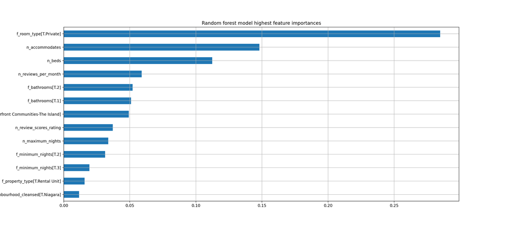

```python
# Plotting feature importances with horizontal bar charts
df_var_imp[df_var_imp.imp > cutoff]\
    .sort_values(by = 'imp')\
    .plot(kind = 'barh',
          x = 'variable', y = 'imp',
          figsize = (18,8), grid = True,
          title = 'Random forest model highest feature importances',
          ylabel = 'Variables', legend = False
         );
plt.show()
```